# Frequency vs Current

Mark Schulist

2022-12-08

# Capacitor

I expect that the current will be greater at higher frequencies since capacitors only pass signals, and there are more signals at higher frequencies.

The current increased with frequency. There is a directly proportional relationship between current and frequency with a capacitor.

$$\begin{align*}
X_c &= \frac{1}{2\pi f C} \\
&= \frac{[s]}{[F]} \\
&= \frac{[s][V]}{[C]} \\
&= \frac{[V]}{[A]}
\end{align*}$$

There is an inverse relationship between capacitive reactance and frequency.

```r
capacitor <- read_csv(here("EECS/frequency_vs_current/input/RLC-capacitor.csv"),
  show_col_types = F
)[1:201, ]
# Splitting the df into many dfs for every 3 columns
cap_dfs <- map(
  seq(1, ncol(capacitor), by = 3),
  ~ capacitor[, .x:(.x + 2)]
)
# Getting the frequency as a column
cap_df <- map_df(
  1:length(cap_dfs),
  ~ cap_dfs[[.x]] %>%
    mutate(frequency = parse_number(colnames(cap_dfs[[.x]][1]))) %>%
    rename(time = 1, current = 2, potential = 3)
)
# Summarizing
cap_summary <- cap_df %>%
  group_by(frequency) %>%
  summarize(max(abs(potential)) / max(abs(current))) %>%
  rename(impedance = 2)
```

Now we can graph the frequency vs impedance of the capacitor.

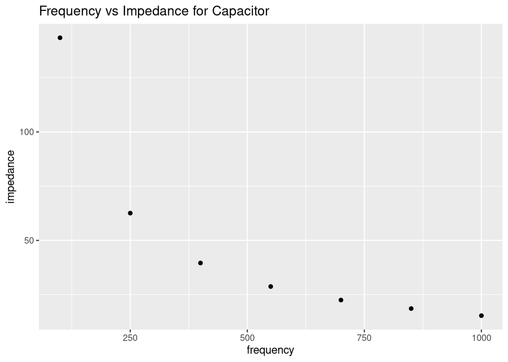

```r
# Graphing
ggplot(cap_summary, aes(frequency, impedance)) +
  geom_point() +
  labs(title = "Frequency vs Impedance for Capacitor")
```

This is nonlinear, so we need to linearize our data. We can do this by doing $\dfrac{1}{\text{impedance}}$.

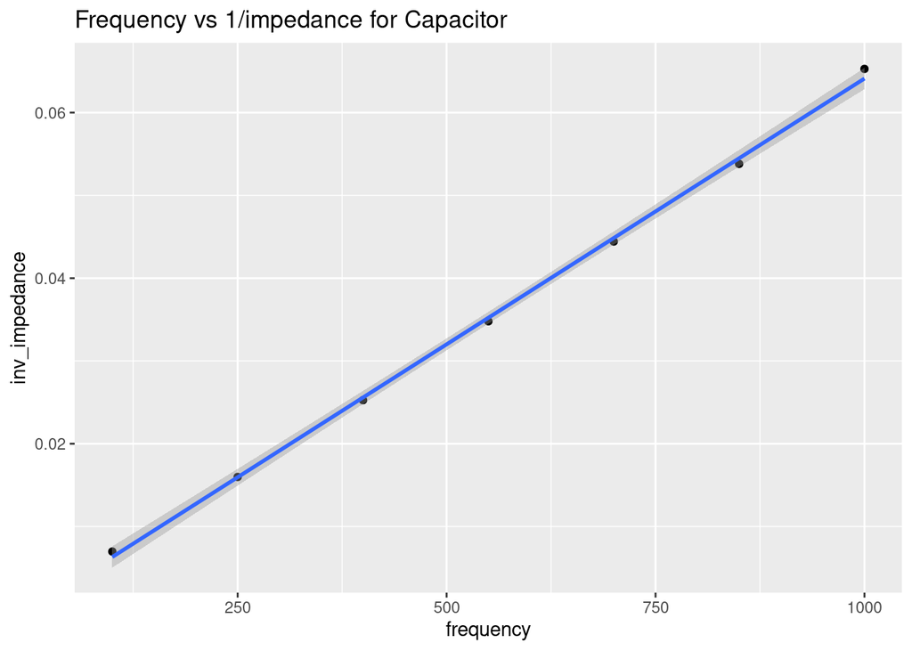

```r
linearized_cap <- cap_summary %>%
  mutate(inv_impedance = 1 / impedance)

ggplot(linearized_cap, aes(frequency, inv_impedance)) +
  geom_point() +
  geom_smooth(method = "lm") +
  labs(title = "Frequency vs 1/impedance for Capacitor")
```

We can fit a linear model to the data.

```r
summary(lm(linearized_cap$inv_impedance ~ linearized_cap$frequency))
```

```
##
## Call:
## lm(formula = linearized_cap$inv_impedance ~ linearized_cap$frequency)
##
## Residuals:
##          1          2          3          4          5          6          7
##  6.553e-04  3.106e-05 -3.205e-04 -4.268e-04 -4.235e-04 -6.780e-04  1.162e-03
##
## Coefficients:
##                            Estimate Std. Error t value Pr(>|t|)
## (Intercept)              -1.052e-04  5.806e-04  -0.181    0.863
## linearized_cap$frequency  6.422e-05  9.268e-07  69.297 1.19e-08 ***
## ---
## Signif. codes:  0 '***' 0.001 '**' 0.01 '*' 0.05 '.' 0.1 ' ' 1
##
## Residual standard error: 0.0007356 on 5 degrees of freedom
## Multiple R-squared:  0.999,  Adjusted R-squared:  0.9988
## F-statistic:  4802 on 1 and 5 DF,  p-value: 1.185e-08
```

$$\frac{1}{\text{Impedance}} = \text{Frequency} \cdot 0.00006422$$

The units for the slope are:

$$\begin{gather*}
\frac{1}{\text{impedance} \cdot \text{frequency}} \\
{[s]^2}
\end{gather*}$$

$$\begin{align*}
X_c &= \frac{1}{2\pi f C} \\
\frac{1}{X_c} &= 2\pi f C
\end{align*}$$

So the slope is equal to $\text{Capacitance} \cdot 2\pi$.

```r
(2 * pi * 10e-6) / 6.422e-05
```

```
## [1] 0.9783845
```

Yes! There is only a small difference between the calculated and empirical values.

# Inductor

I expect there be less current at higher frequencies since inductors resist changes in current.

There is an inverse relationship between the frequency and current through a inductor.

```r
inductor <- read_csv(here("EECS/frequency_vs_current/input/RLC-inductor.csv"),
  show_col_types = F
)
# Splitting the df into many dfs for every 3 columns
ind_dfs <- map(
  seq(1, ncol(inductor), by = 3),
  ~ inductor[, .x:(.x + 2)]
)
# Getting the frequency as a column
ind_df <- map_df(
  1:length(ind_dfs),
  ~ ind_dfs[[.x]] %>%
    mutate(frequency = parse_number(colnames(ind_dfs[[.x]][1]))) %>%
    rename(time = 1, current = 2, potential = 3)
)
# Summarizing
ind_summary <- ind_df %>%
  group_by(frequency) %>%
  summarize(max(abs(potential)) / max(abs(current))) %>%
  rename(impedance = 2)
```

Now we can graph frequency vs impedance for the inductor.

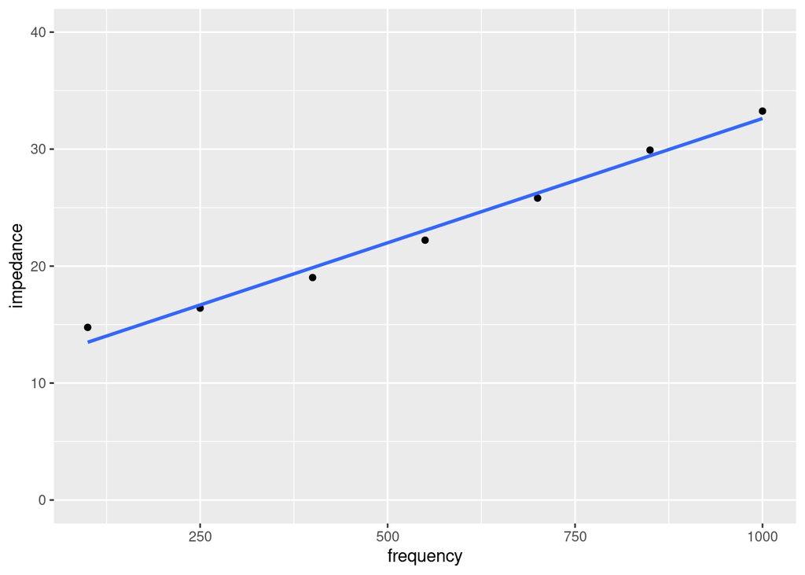

```r
ggplot(ind_summary, aes(frequency, impedance)) +
  geom_point() +
  geom_smooth(method = "lm", se = F) +
  ylim(c(0, 40))
```

```r
labs(title = "Frequency vs Impedance of Inductor")
```

```
## $title
## [1] "Frequency vs Impedance of Inductor"
##
## attr(,"class")
## [1] "labels"
```

```r
summary(lm(impedance ~ frequency, data = ind_summary))
```

```
##
## Call:
## lm(formula = impedance ~ frequency, data = ind_summary)
##
## Residuals:
##       1       2       3       4       5       6       7
##  1.2705 -0.2680 -0.8472 -0.8378 -0.4320  0.4834  0.6311
##
## Coefficients:
##              Estimate Std. Error t value Pr(>|t|)
## (Intercept) 11.364404   0.699262   16.25 1.61e-05 ***
## frequency    0.021255   0.001116   19.04 7.36e-06 ***
## ---
## Signif. codes:  0 '***' 0.001 '**' 0.01 '*' 0.05 '.' 0.1 ' ' 1
##
## Residual standard error: 0.8859 on 5 degrees of freedom
## Multiple R-squared:  0.9864, Adjusted R-squared:  0.9837
## F-statistic: 362.7 on 1 and 5 DF,  p-value: 7.359e-06
```

There is linear relationship between the frequency and the inductance, but their is not a proportional relationship. This is because there is also the resistance of the circuit, which is $10 \Omega$ in this case. Resistors are not affected by frequency, so the resistance is the y-intercept, which in this case is 11, very close to 10.

# Complete RLC Circuit

The lamp glows the brightest around 700 Hz. It is dimmer at higher and lower frequencies.

The iron core make the frequency when the bulb is brightest decrease because the core increases the inductance, which decreases frequency.

```r
rlc <- read_csv(here("EECS/frequency_vs_current/input/rcl-full.csv"),
  show_col_types = F
)
# Splitting the df into many dfs for every 3 columns
rlc_dfs <- map(
  seq(1, ncol(rlc), by = 3),
  ~ rlc[, .x:(.x + 2)]
)
# Getting the frequency as a column
rlc_df <- map_df(
  1:length(rlc_dfs),
  ~ rlc_dfs[[.x]] %>%
    mutate(frequency = parse_number(colnames(rlc_dfs[[.x]][1]))) %>%
    rename(time = 1, current = 2, potential = 3)
)
# Summarizing
rlc_summary <- rlc_df %>%
  group_by(frequency) %>%
  summarize(current = max(abs(current)))
```

Graphing current vs frequency

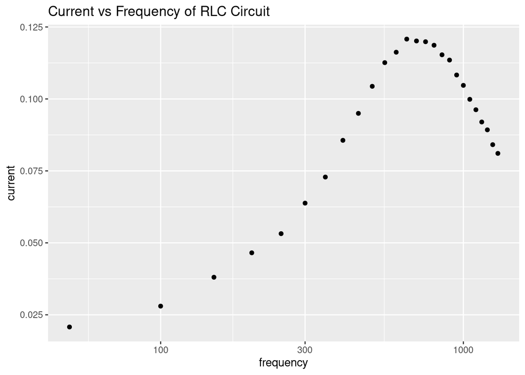

```r
ggplot(rlc_summary, aes(frequency, current)) +
  geom_point() +
  scale_x_log10() +
  labs(title = "Current vs Frequency of RLC Circuit")
```

$$\begin{align*}
\frac{1}{2 \pi fL} &= 2 \pi fC \\
1 &= 4 \pi^2 f^2CL \\
f^2 &= \frac{1}{4 \pi CL} \\
f &= \frac{1}{2 \pi \sqrt{CL}}
\end{align*}$$

Now we can plug in the values that we had in our circuit.

$$\begin{align*}
f &= \frac{1}{2 \pi \sqrt{0.005 \cdot 0.00001}} \\
f &\approx 711.76
\end{align*}$$

This matches our graph, which shows that the frequency range 650–750 is where the most current flows through the circuit.